# CHINOOK DATABASE PROJECT - UDACITY DATA FUNDAMENTALS II

## INTRODUCTION

> For this project, I was given a sqlite database of a music store called Chinook. The goal is to assist the Chinook team with understanding the media in their store, their customers and employees, and their invoice information.

> In order to describe relevant information regarding Chinook database, I will be using Python DS packages such as Pandas, Numpy and Matplotlib, as well as Sql3 to run queries. The analysis will all be based on descriptive statistics only. Below follows the Chinook schema:

[figure not shown]

```python
#import relevant packages for this analysis and define
#a function that queries the db and transforms it into a
#pandas dataframe.
import sqlite3
import pandas as pd
import numpy as np
import matplotlib.pyplot as plt
import seaborn as sns

% matplotlib inline

def import_query (script):
    """
    This function goal is to import a query result from
    a database and convert it into a pandas dataframe.
    Imput: a script written in SQL language
    Output: the script result in dataframe format
    """
    conn = sqlite3.connect("/Users/Gavrik/Desktop/Programming/Udacity/Data_Science_Fundamentals_II/chinook_db/chinook.db")
    cursor = conn.cursor()
    cursor.execute(script)
    df_columns = [column[0] for column in cursor.description]
    results = cursor.fetchall()
    conn.close()
    return pd.DataFrame(results, columns = df_columns)
```

## How is the revenue evolution of the 12 latest months?

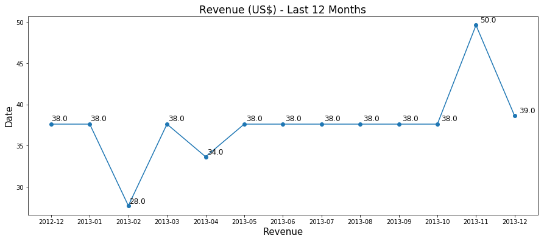

```python
script1 = """SELECT STRFTIME('%Y-%m', InvoiceDate) as date,
                SUM(Total) as revenue
             FROM Invoice
             WHERE date >= '2012-12'
             GROUP BY date
             ORDER BY date"""

df = import_query(script1)
fig = plt.figure(figsize=(15, 6))
ax = fig.add_subplot(111)
rects = plt.plot(df['date'], df['revenue'],marker = 'o')
plt.title('Revenue (US$) - Last 12 Months',fontsize=17)
plt.xlabel('Revenue',fontsize=15)
plt.ylabel('Date',fontsize=15)


for i,j in df['revenue'].round().items():
    ax.annotate(s= str(j), xy=(i, j), xytext=(i*1.01, j)
               ,fontsize=12)
```

Revenue for the past 12 months looks quite steady, with low variations from month to month.

## Which are the 10 countries with the highest revenue? Is there a difference in their average ticket?

```python
script = """SELECT c.Country as country,
                COUNT(i.InvoiceId) as invoices,
                SUM(i.Total) as revenue,
                SUM(i.Total)/COUNT(i.InvoiceId) as avg_ticket
            FROM Invoice i
            JOIN Customer c
            ON i.CustomerId = c.CustomerId
            GROUP BY BillingCountry
            ORDER BY COUNT(*) DESC, revenue DESC"""

df = import_query(script)
df10 = df.head(10)
df10
```

|  | country | invoices | revenue | avg_ticket |
| --- | --- | --- | --- | --- |
| 0 | USA | 91 | 523.06 | 5.747912 |
| 1 | Canada | 56 | 303.96 | 5.427857 |
| 2 | France | 35 | 195.10 | 5.574286 |
| 3 | Brazil | 35 | 190.10 | 5.431429 |
| 4 | Germany | 28 | 156.48 | 5.588571 |
| 5 | United Kingdom | 21 | 112.86 | 5.374286 |
| 6 | Czech Republic | 14 | 90.24 | 6.445714 |
| 7 | Portugal | 14 | 77.24 | 5.517143 |
| 8 | India | 13 | 75.26 | 5.789231 |
| 9 | Chile | 7 | 46.62 | 6.660000 |

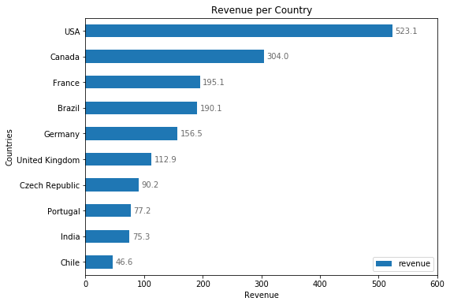

```python
df_rev = df10[['country','revenue']]

ax = df_rev.set_index('country').plot(kind='barh', figsize=(8, 6))
plt.title('Revenue per Country')
plt.ylabel('Countries')
plt.xlabel('Revenue');
plt.xlim(0, 600)
ax.invert_yaxis()

for i, v in enumerate(df_rev['revenue']):
    ax.text(v+ 5 , i + .1, str(round(v,1)), color='dimgrey')
```

## Which artists are most listened to? What about genres?

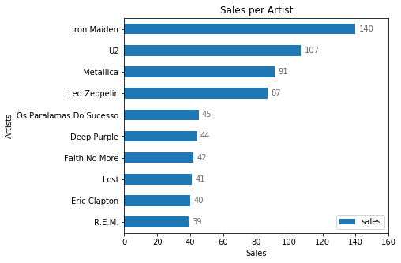

```python
script = """SELECT a.Name as artist,
                g.Name as genre,
                COUNT(i.InvoiceId) as sales
            FROM Invoice i
            JOIN InvoiceLine il
            ON i.InvoiceId = il.InvoiceId
            JOIN Track t
            ON il.TrackId = t.TrackId
            JOIN Genre g
            ON t.GenreId = g.GenreId
            JOIN Album ai
            ON t.AlbumId = ai.AlbumId
            JOIN Artist a
            ON ai.ArtistId = a.ArtistId
            GROUP BY artist
            ORDER BY sales DESC"""

df = import_query(script)

ax = df.head(10).set_index('artist').plot(kind='barh', figsize=(6, 5))
plt.title('Sales per Artist')
plt.ylabel('Artists')
plt.xlabel('Sales');
plt.xlim(0, 160)
ax.invert_yaxis()

for i, v in enumerate(df.head(10)['sales']):
    ax.text(v+ 2 , i + .1, str(v), color='dimgrey')
```

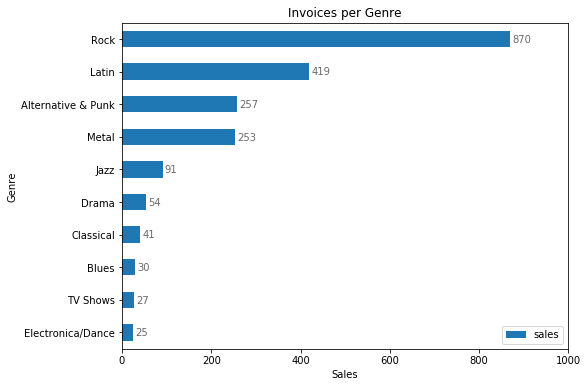

```python
script = """SELECT genre, SUM(sales) as sales
            FROM(
                SELECT a.Name as artist,
                g.Name as genre,
                COUNT(i.InvoiceId) as sales
                FROM Invoice i
                INNER JOIN InvoiceLine il
                ON i.InvoiceId = il.InvoiceId
                INNER JOIN Track t
                ON il.TrackId = t.TrackId
                INNER JOIN Genre g
                ON t.GenreId = g.GenreId
                INNER JOIN Album ai
                ON t.AlbumId = ai.AlbumId
                INNER JOIN Artist a
                ON ai.ArtistId = a.ArtistId
                GROUP BY artist
                ORDER BY sales DESC) as t_table
            GROUP BY genre
            ORDER BY sales DESC"""

df = import_query(script)
df.head(10).set_index('genre')

ax = df.head(10).set_index('genre').plot(kind='barh', figsize=(8, 6))
plt.title('Invoices per Genre')
plt.ylabel('Genre')
plt.xlabel('Sales');
plt.xlim(0, 1000)
ax.invert_yaxis()

for i, v in enumerate(df.head(10)['sales']):
    ax.text(v+ 5 , i + .1, str(v), color='dimgrey')
```

Iron Maiden (a personal favourite) is the most listened artist, while Rock is the favourite genre.

## Should we try to target customers with different bands and genres to expand their preferences, or customers are more likely to buy only songs from the same artist and genre?

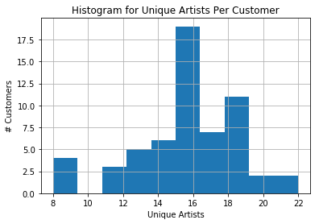

```python
script = """SELECT c.FirstName || ' ' || c.LastName as customer_name,
         COUNT(DISTINCT(t.GenreId)) as different_genres,
         COUNT(DISTINCT(a.ArtistId)) as different_artists,
         a.Name as artist,
         g.Name as genre
         --SUM(i.Total) as amount_spent
         FROM Customer c
         INNER JOIN Invoice i
         ON c.CustomerId = i.CustomerId
         INNER JOIN InvoiceLine il
         ON i.InvoiceId = il.InvoiceId
         INNER JOIN Track t
         ON il.TrackId = t.TrackId
         INNER JOIN Genre g
         ON t.GenreId = g.GenreId
         INNER JOIN Album ai
         ON t.AlbumId = ai.AlbumId
         INNER JOIN Artist a
         ON ai.ArtistId = a.ArtistId
         WHERE genre != 'TV Shows'
         GROUP BY customer_name"""

df = import_query(script)
df['different_artists'].hist()
plt.title ('Histogram for Unique Artists Per Customer')
plt.xlabel('Unique Artists')
plt.ylabel ('# Customers');
```

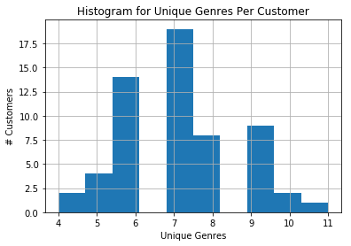

```python
df['different_genres'].hist()
plt.title ('Histogram for Unique Genres Per Customer')
plt.xlabel('Unique Genres')
plt.ylabel ('# Customers');
```

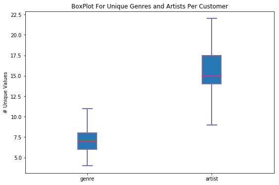

```python
fig = plt.figure(1, figsize=(9, 6))
ax = fig.add_subplot(111)
ax1 = df['different_genres']
ax2 = df['different_artists']

data_to_plot = [ax1,ax2]
bp = ax.boxplot(data_to_plot, meanline=True, showmeans=True, showcaps=True,
           showbox=True, showfliers=False, patch_artist=True)
ax.set_xticklabels(['genre','artist'])
for box in bp['boxes']:
    box.set( color='#7570b3', linewidth=2)
    box.set( facecolor = '#2678b2ff' )

## change color and linewidth of the whiskers
for whisker in bp['whiskers']:
    whisker.set(color='#7570b3', linewidth=2)

## change color and linewidth of the caps
for cap in bp['caps']:
    cap.set(color='#7570b3', linewidth=2)

## change color and linewidth of the medians
for median in bp['medians']:
    median.set(color='#e7298a', linewidth=2)

## change the style of fliers and their fill
for flier in bp['fliers']:
    flier.set(marker='o', color='#e7298a', alpha=0.5)
ax.set_title('BoxPlot For Unique Genres and Artists Per Customer')
ax.set_ylabel('# Unique Values');
```

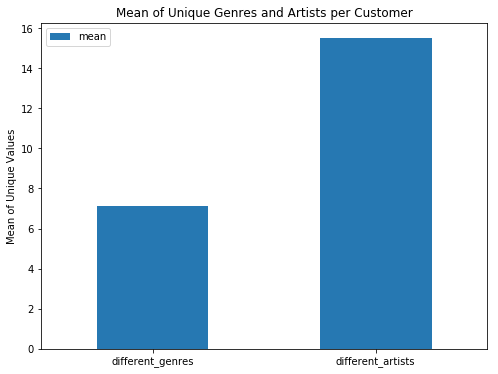

```python
kibe = df[['different_genres','different_artists']]
kibe.mean().plot(kind='bar', color='#2678b2ff', figsize=(8,6), label='mean')
plt.xticks(rotation=0)
plt.ylabel('Mean of Unique Values')
plt.title('Mean of Unique Genres and Artists per Customer')
plt.legend()
```

```python
kibe.mean()
```

```
different_genres      7.135593
different_artists    15.491525
dtype: float64
```

## Who is the top sales support agent among all employees of all time?

```python
script = """SELECT e.FirstName || ' ' || e.LastName as employee_name,
                e.Title as title,
                COUNT(i.InvoiceId) as sales
            FROM Employee e
            LEFT JOIN Customer c
            ON e.EmployeeId = c.SupportRepId
            LEFT JOIN Invoice i
            ON c.CustomerId = i.CustomerId
            GROUP BY employee_name
            ORDER BY sales DESC"""

df = import_query(script)
df
```

|  | employee_name | title | sales |
| --- | --- | --- | --- |
| 0 | Jane Peacock | Sales Support Agent | 146 |
| 1 | Margaret Park | Sales Support Agent | 140 |
| 2 | Steve Johnson | Sales Support Agent | 126 |
| 3 | Andrew Adams | General Manager | 0 |
| 4 | Laura Callahan | IT Staff | 0 |
| 5 | Michael Mitchell | IT Manager | 0 |
| 6 | Nancy Edwards | Sales Manager | 0 |
| 7 | Robert King | IT Staff | 0 |

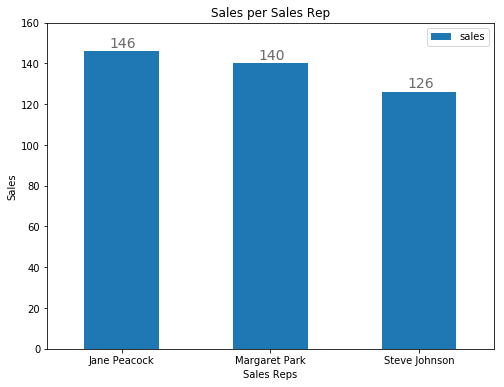

```python
sales_sup_only = df.query("title == 'Sales Support Agent'")

ax = sales_sup_only.set_index('employee_name').plot(kind='bar', )
plt.xlabel('Sales Reps')
plt.xticks(rotation=0)
plt.ylabel('Sales')
plt.ylim(0, 160)
plt.title('Sales per Sales Rep');

for i, v in enumerate(sales_sup_only['sales']):
    ax.text(i-0.08 , v+2, str(v), color='dimgrey', fontsize=14)
```

As expected, only the sales-related employees have computed sales (Nancy, the sales manager, must have a more managerial role). From the Support Agents, congratulations to Jane, the top performer!

## How each sales rep did in the last 12 months in terms of monthly sales generated?

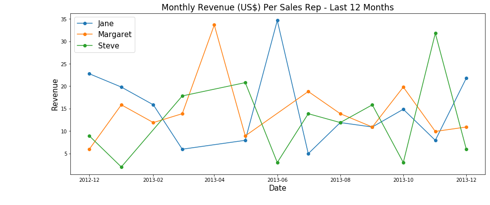

```python
script = """SELECT STRFTIME('%Y-%m', i.InvoiceDate) as date,
                e.FirstName || ' ' || e.LastName as employee_name,
                SUM(i.Total) as revenue
            FROM Invoice i
            JOIN Customer c
            ON c.CustomerId = i.CustomerId
            JOIN Employee e
            ON c.SupportRepId = e.EmployeeId
            WHERE date >= '2012-12'
            GROUP BY date, employee_name
            ORDER BY date"""

df = import_query(script)
df['date'] = pd.to_datetime(df['date'])

df_jane = df.query('employee_name == "Jane Peacock"')
df_margaret = df.query('employee_name == "Margaret Park"')
df_steve = df.query('employee_name == "Steve Johnson"')

fig = plt.figure(figsize=(15, 6))
ax = fig.add_subplot(111)
ax1 = plt.plot(df_jane['date'], df_jane['revenue'],marker = 'o', label='Jane')
ax2 = plt.plot(df_margaret['date'], df_margaret['revenue'],marker = 'o', label='Margaret')
ax3 = plt.plot(df_steve['date'], df_steve['revenue'],marker = 'o', label='Steve')
plt.title('Monthly Revenue (US$) Per Sales Rep - Last 12 Months',fontsize=17)
plt.xlabel('Date',fontsize=15)
plt.ylabel('Revenue',fontsize=15)
plt.legend(fontsize = 15)


for i,j in df['revenue'].round().items():
    ax.annotate(s= str(j), xy=(i, j), xytext=(i*1.01, j)
               ,fontsize=12)
```

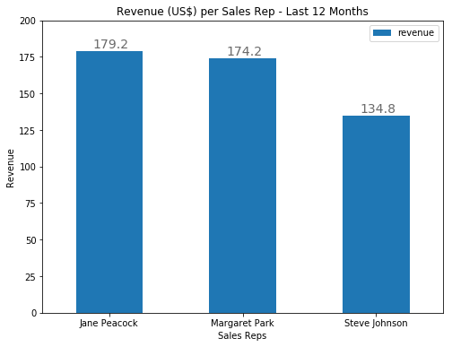

```python
script = """SELECT  e.FirstName || ' ' || e.LastName as employee_name,
                SUM(i.Total) as revenue
            FROM Invoice i
            JOIN Customer c
            ON c.CustomerId = i.CustomerId
            JOIN Employee e
            ON c.SupportRepId = e.EmployeeId
            WHERE STRFTIME('%Y-%m', i.InvoiceDate) >= '2012-12'
            GROUP BY employee_name
            ORDER BY revenue DESC"""

df = import_query(script)

ax = df.set_index('employee_name').plot(kind='bar', figsize=(8,6))
plt.xlabel('Sales Reps')
plt.xticks(rotation=0)
plt.ylabel('Revenue')
plt.ylim(0,200)
plt.title('Revenue (US$) per Sales Rep - Last 12 Months');

for i, v in enumerate(df['revenue']):
    ax.text(i-0.12 , v+2, str(round(v,1)), color='dimgrey', fontsize=14)
```

The sales reps had a well-balanced sales performance during 2013, with Jane reaching a slightly higher peak when compared to Margaret.